# Lecture 7. Data visualization - Points with trending curves

Carlos Ramirez Alvarez

10/8/2019

Here, we will exemplify how to make a points plot using data from magnitud of tremors in Mexico. As done previously, we will load the tremors data into R as follows:

```r
## Find the data in http://www2.ssn.unam.mx:8080/catalogo/
tremors <- read.csv('../data/tremors.csv',
                    skip = 4,
                    header = TRUE,
                    stringsAsFactors = FALSE)
```

In this case, we will plot the dynamics of tremors magnitud, that is, time *vs* magnitud.

In order to do that we will preprocess the data with the following steps:

- NAs are removed
- Date and times columns are concatenated and parsed using lubridate
- Magnitud is casted to numeric

```r
library(dplyr)
library(lubridate)

## Processing the data
tremors.p <- tremors %>%
                 na.omit %>%
                   mutate(
                      ## paste data and time cols
                      Fecha_Hora = paste(Fecha, Hora),
                      ## parsing time with lubridate
                      time = ymd_hms(Fecha_Hora),
                      ## casting value to numeric
                      Magnitud = as.numeric(Magnitud)
                     ) %>%
             filter(
                     time > '1985-01-01' & ! is.na(Magnitud)
)
```

Now, we can create the points plot using the geometry `geom_point()` ggplot component.

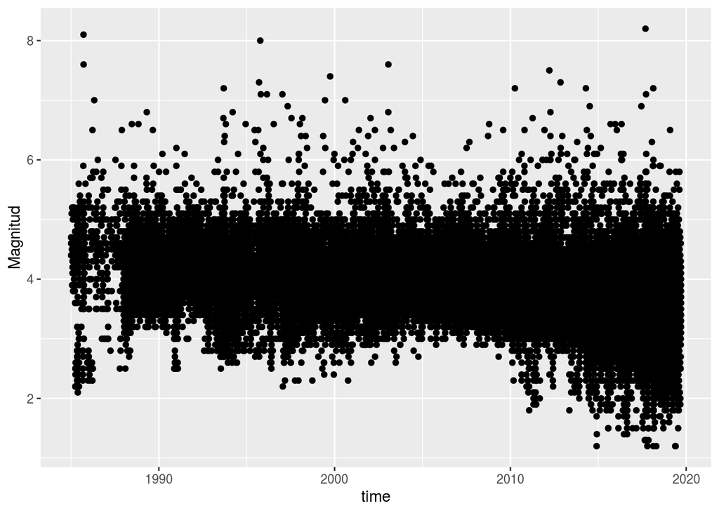

```r
library(ggplot2)

## plotting
tremors.p %>%
        ggplot(aes(x=time, y=Magnitud)) +
             geom_point()
```

That’s a very simple points plot. We will add a line showing the trends of the magnitud dynamic using `geom_smooth`. This smooth line is defined by taking intervals in the x axis, calculating the local mean and drawing a line passing through that mean values (see *?geom_smooth*). Additionally, we will add a nice formating or theme using `theme_set()` ggplot function (see *?theme_set* for more themes).

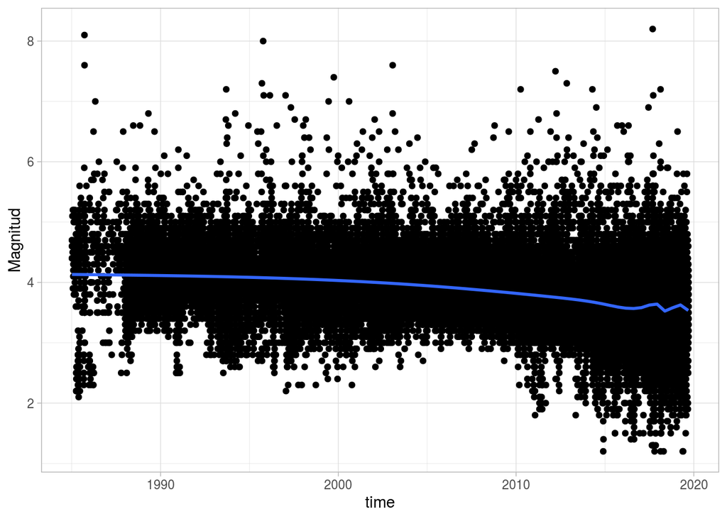

```r
## setting nice format
theme_set(theme_light())

## plotting
tremors.p %>%
        ggplot(aes(x=time, y=Magnitud)) +
             geom_point() +
                geom_smooth()
```

We can use another types of curves to fit the data in order to see trends. For example, we can fit a linear model by using `geom_smooth(method = 'lm')` as follows.

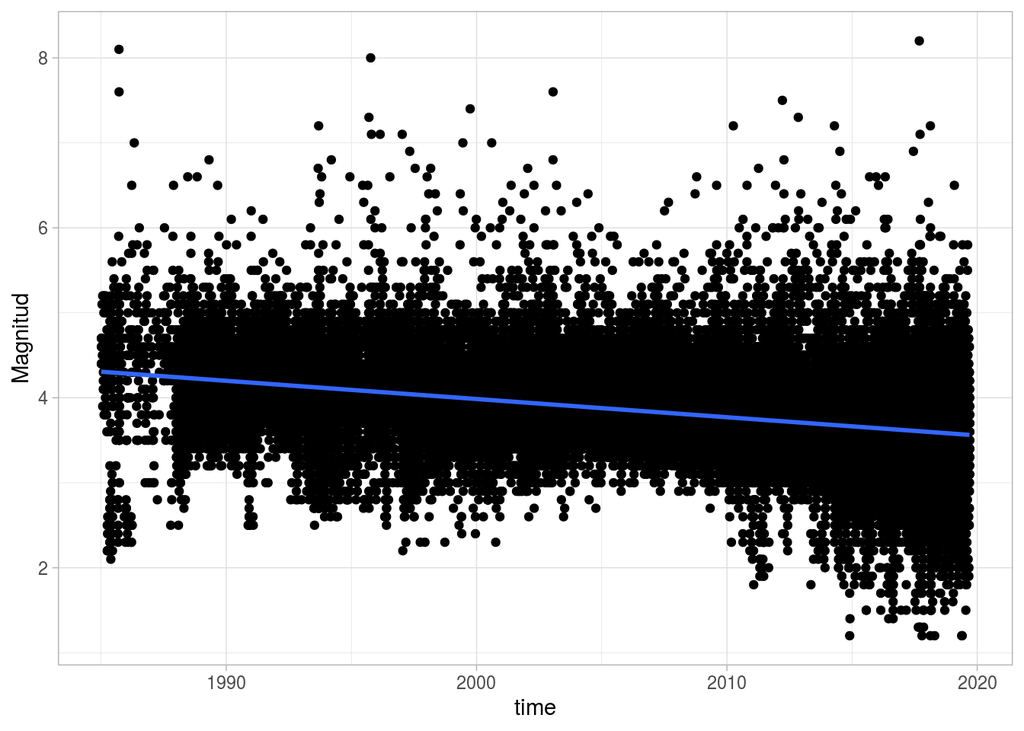

```r
## setting nice format
theme_set(theme_light())

## plotting
tremors.p %>%
        ggplot(aes(x=time, y=Magnitud)) +
             geom_point() +
                geom_smooth(method = 'lm')
```